# Assignment 6

Sam Raby

11/16/2016

Assignment 6

For this assignment we will be using the dataset Food_inspections.csv which is recent data pertaining to health code inspections and violations in Chicago. It is a larger dataset than we usually use, so you will find some tasks take a bit longer.

Data:

```r
food <- read.csv("/Volumes/courses/QAC/qac251/course_materials/Code and Data/Food_inspections.csv")
```

1. Check the structure of the data. Ensure numeric values have been read in as numeric and date variables have been read in as dates. Convert any variables if necessary.

```r
require(mosaic)
require(reshape2)
food <- mutate(food, Inspection.Date = as.Date(Inspection.Date, format = "%m/%d/%y"))
```

2. Construct a new variable in this dataset to determine which day of the week each date corresponds to. (HINT: We did this on our first day with ggplot). Construct a visual to determine whether inspections occur more frequently on a particular day of the week.

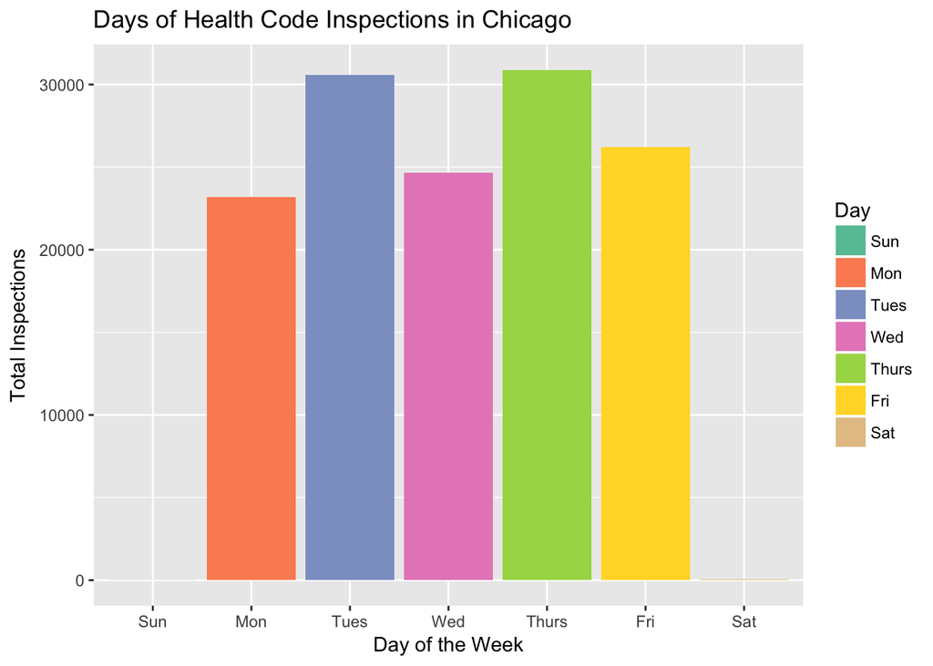

```r
require(lubridate)
food$day = wday(food$Inspection.Date, label = TRUE)

require(ggplot2)
require(RColorBrewer)

ggplot(data = food)+
  geom_bar(aes(x = day, fill = day)) +
  scale_fill_brewer("Day",palette = "Set2") +
  xlab("Day of the Week") +
  ylab("Total Inspections") +
  ggtitle("Days of Health Code Inspections in Chicago")
```

3. Construct a new variable that indicates (with a 0 or 1) whether an inspection failed. Find the proportion of inspections that failed for each day of the week. Is there a higher/lower tendency for inspections to fail on a particular day?

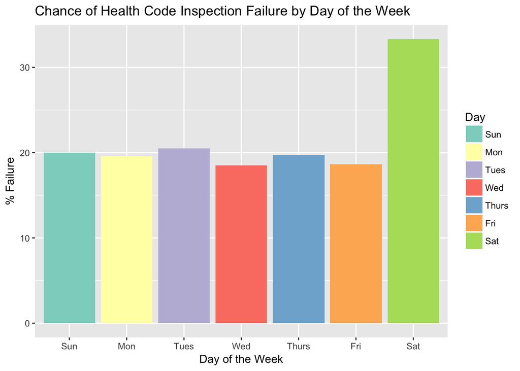

```r
food$Fail = 0
food$Fail[food$Results == "Fail"] = 1

ggplot(data = food)+
  stat_summary(aes(x = day, y = Fail*100, fill = day), fun.y = mean, geom = "bar") +
  scale_fill_brewer("Day",palette = "Set3") +
  xlab("Day of the Week") +
  ylab("% Failure") +
  ggtitle("Chance of Health Code Inspection Failure by Day of the Week")
```

From this visualization, it seems that inspections that occur on Saturday have a much higher chance of failing than ones that occur on other days of the week.

4. Construct a visual to determine which area(s) in Chicago are inspected frequently. State any interesting findings.

```r
require(leaflet)

leaflet(food) %>%
  addProviderTiles("Stamen.Toner") %>%
  addCircles(~Longitude, ~Latitude, popup=paste("Inspected Business: ",food$DBA.Name), weight = 3, radius=100, color="#DB104A", fillColor = "#DB104A", fillOpacity = 1, opacity = 1, stroke = TRUE) %>%
  addLegend("bottomright",colors = "#DB104A", labels = "One Inspection", title = "Health Inspections, Chicago")
```

[output not shown]

5. Construct a visual that allows you to easily assess the result and risk attached to each inspection. State any interesting findings.

```r
Color = colorFactor(c("#1a9850","#d73027"), domain = food$Fail)

leaflet(food) %>%
  addProviderTiles("Stamen.Toner") %>%
  addCircles(~Longitude,
             ~Latitude,
             popup=paste("Business:", food$DBA.Name, "<br>",
                         "Inspection Result:", food$Results, "<br>",
                         "Risk:", food$Risk),
             weight = 3, radius=250, opacity = 1,
             color=~Color(Fail), fillOpacity = 1, fillColor =~Color(Fail)) %>%
  addLegend("bottomright",colors = c("#1a9850","#d73027"), labels = c("Pass","Fail"), title = "Health Inspection Outcomes, Chicago")
```

[output not shown]

6. Using this data, construct an additional question of interest. Construct an appropriate visualization to answer that question and describe your findings.

Questions of Interest: How does the rate of inspection failure differ with type of establishment?

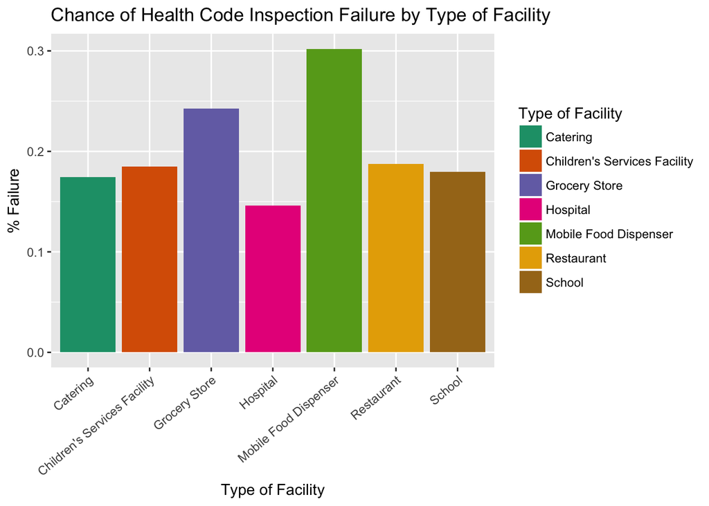

```r
food2 = subset(food, Facility.Type == "School" | Facility.Type == "Restaurant" | Facility.Type == "Mobile Food Dispenser" | Facility.Type == "Hospital" | Facility.Type == "Grocery Store" | Facility.Type == "Children's Services Facility" | Facility.Type == "Catering")

ggplot(data = food2)+
  stat_summary(aes(x = Facility.Type, y = Fail, fill = Facility.Type), fun.y = mean, geom = "bar") +
  scale_fill_brewer("Type of Facility",palette = "Dark2") +
  xlab("Type of Facility") +
  ylab("% Failure") +
  ggtitle("Chance of Health Code Inspection Failure by Type of Facility") +
  theme(axis.text.x = element_text(angle = 40, hjust = 1))
```

This visualization indicates that facilities like mobile food dispensors and grocery stores have a much higher rate of failing inspection than other facilities shown, when hospitals have a considerably lower rate of failing inspection.